# Optimal Treatment Analysis

## Outcome Variable

**Outcome Variable:** haz

## Predictor Variables

**Intervention Variable:** parity

**Adjustment Set:**

- arm
- W_mage
- meducyrs
- feducyrs
- hhwealth_quart
- W_mhtcm
- vagbrth
- W_nrooms
- impsan
- delta_W_mage
- delta_meducyrs
- delta_feducyrs
- delta_hhwealth_quart
- delta_W_mhtcm
- delta_vagbrth
- delta_W_nrooms
- delta_impsan

## Stratifying Variables

The analysis was stratified on these variable(s):

- agecat
- studyid
- country

## Data Summary

| agecat | studyid | country | parity | n_cell | n |
| --- | --- | --- | --- | --- | --- |
| Birth | ki1000304b-SAS-CompFeed | INDIA | 1 | 47 | 187 |
| Birth | ki1000304b-SAS-CompFeed | INDIA | 2 | 53 | 187 |
| Birth | ki1000304b-SAS-CompFeed | INDIA | 3+ | 87 | 187 |
| Birth | ki1101329-Keneba | GAMBIA | 1 | 156 | 1407 |
| Birth | ki1101329-Keneba | GAMBIA | 2 | 146 | 1407 |
| Birth | ki1101329-Keneba | GAMBIA | 3+ | 1105 | 1407 |
| Birth | ki1126311-ZVITAMBO | ZIMBABWE | 1 | 5972 | 13829 |
| Birth | ki1126311-ZVITAMBO | ZIMBABWE | 2 | 4125 | 13829 |
| Birth | ki1126311-ZVITAMBO | ZIMBABWE | 3+ | 3732 | 13829 |
| Birth | ki1135781-COHORTS | GUATEMALA | 1 | 112 | 852 |
| Birth | ki1135781-COHORTS | GUATEMALA | 2 | 137 | 852 |
| Birth | ki1135781-COHORTS | GUATEMALA | 3+ | 603 | 852 |
| Birth | ki1135781-COHORTS | INDIA | 1 | 696 | 4122 |
| Birth | ki1135781-COHORTS | INDIA | 2 | 1037 | 4122 |
| Birth | ki1135781-COHORTS | INDIA | 3+ | 2389 | 4122 |
| Birth | ki1135781-COHORTS | PHILIPPINES | 1 | 675 | 3050 |
| Birth | ki1135781-COHORTS | PHILIPPINES | 2 | 687 | 3050 |
| Birth | ki1135781-COHORTS | PHILIPPINES | 3+ | 1688 | 3050 |
| Birth | kiGH5241-JiVitA-3 | BANGLADESH | 1 | 6271 | 19594 |
| Birth | kiGH5241-JiVitA-3 | BANGLADESH | 2 | 6710 | 19594 |
| Birth | kiGH5241-JiVitA-3 | BANGLADESH | 3+ | 6613 | 19594 |
| 6 months | ki1000304b-SAS-CompFeed | INDIA | 1 | 392 | 1336 |
| 6 months | ki1000304b-SAS-CompFeed | INDIA | 2 | 304 | 1336 |
| 6 months | ki1000304b-SAS-CompFeed | INDIA | 3+ | 640 | 1336 |
| 6 months | ki1000304b-SAS-FoodSuppl | INDIA | 1 | 72 | 373 |
| 6 months | ki1000304b-SAS-FoodSuppl | INDIA | 2 | 84 | 373 |
| 6 months | ki1000304b-SAS-FoodSuppl | INDIA | 3+ | 217 | 373 |
| 6 months | ki1017093b-PROVIDE | BANGLADESH | 1 | 211 | 583 |
| 6 months | ki1017093b-PROVIDE | BANGLADESH | 2 | 212 | 583 |
| 6 months | ki1017093b-PROVIDE | BANGLADESH | 3+ | 160 | 583 |

[output cut: 51 more lines]

The following strata were considered:

- agecat: 24 months, studyid: ki1017093b-PROVIDE, country: BANGLADESH
- agecat: 24 months, studyid: ki1066203-TanzaniaChild2, country: TANZANIA, UNITED REPUBLIC OF
- agecat: 24 months, studyid: ki1101329-Keneba, country: GAMBIA
- agecat: 24 months, studyid: ki1113344-GMS-Nepal, country: NEPAL
- agecat: 24 months, studyid: ki1126311-ZVITAMBO, country: ZIMBABWE
- agecat: 24 months, studyid: ki1135781-COHORTS, country: GUATEMALA
- agecat: 24 months, studyid: ki1135781-COHORTS, country: INDIA
- agecat: 24 months, studyid: ki1135781-COHORTS, country: PHILIPPINES
- agecat: 24 months, studyid: kiGH5241-JiVitA-3, country: BANGLADESH
- agecat: 6 months, studyid: ki1000304b-SAS-CompFeed, country: INDIA
- agecat: 6 months, studyid: ki1000304b-SAS-FoodSuppl, country: INDIA
- agecat: 6 months, studyid: ki1017093b-PROVIDE, country: BANGLADESH
- agecat: 6 months, studyid: ki1066203-TanzaniaChild2, country: TANZANIA, UNITED REPUBLIC OF
- agecat: 6 months, studyid: ki1101329-Keneba, country: GAMBIA
- agecat: 6 months, studyid: ki1113344-GMS-Nepal, country: NEPAL
- agecat: 6 months, studyid: ki1126311-ZVITAMBO, country: ZIMBABWE
- agecat: 6 months, studyid: ki1135781-COHORTS, country: GUATEMALA
- agecat: 6 months, studyid: ki1135781-COHORTS, country: INDIA
- agecat: 6 months, studyid: ki1135781-COHORTS, country: PHILIPPINES
- agecat: 6 months, studyid: kiGH5241-JiVitA-3, country: BANGLADESH
- agecat: Birth, studyid: ki1000304b-SAS-CompFeed, country: INDIA
- agecat: Birth, studyid: ki1101329-Keneba, country: GAMBIA
- agecat: Birth, studyid: ki1126311-ZVITAMBO, country: ZIMBABWE
- agecat: Birth, studyid: ki1135781-COHORTS, country: GUATEMALA
- agecat: Birth, studyid: ki1135781-COHORTS, country: INDIA
- agecat: Birth, studyid: ki1135781-COHORTS, country: PHILIPPINES
- agecat: Birth, studyid: kiGH5241-JiVitA-3, country: BANGLADESH

### Dropped Strata

Some strata were dropped due to rare outcomes:

- agecat: 24 months, studyid: ki1066203-TanzaniaChild2, country: TANZANIA, UNITED REPUBLIC OF

## Methods Detail

We’re interested in the causal parameters $E[Y_a]$ for all values of $a \in \mathcal{A}$. These parameters represent the mean outcome if, possibly contrary to fact, we intervened to set all units to have $A=a$. Under the randomization and positivity assumptions, these are identified by the statistical parameters $\psi_a=E_W[E_{Y|A,W}(Y|A=a,W)]$. In addition, we’re interested in the mean of $Y$, $E[Y]$ under no intervention (the observed mean). We will estimate these parameters by using SuperLearner to fit the relevant likelihood factors – $E_{Y|A,W}(Y|A=a,W)$ and $p(A=a|W)$, and then updating our likelihood fit using a joint TMLE.

For unadjusted analyses ($W=\{\}$), initial likelihoods were estimated using Lrnr_glm to estimate the simple $E(Y|A)$ and Lrnr_mean to estimate $p(A)$. For adjusted analyses, a small library containing Lrnr_glmnet, Lrnr_xgboost, and Lrnr_mean was used.

Having estimated these parameters, we will then use the delta method to estimate relative risks and attributable risks relative to a prespecified baseline level of $A$.

# Results Detail

## Results Plots

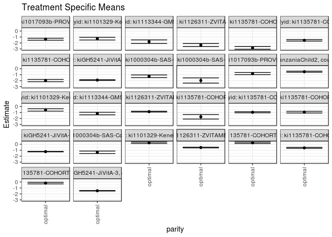

## Results Table

### Parameter: TSM

| agecat | studyid | country | intervention_level | baseline_level | estimate | ci_lower | ci_upper |
| --- | --- | --- | --- | --- | --- | --- | --- |
| Birth | ki1000304b-SAS-CompFeed | INDIA | optimal | observed | -1.3502092 | -1.5583087 | -1.1421097 |
| Birth | ki1101329-Keneba | GAMBIA | optimal | observed | 0.2512748 | 0.1316687 | 0.3708809 |
| Birth | ki1126311-ZVITAMBO | ZIMBABWE | optimal | observed | -0.5508247 | -0.6127256 | -0.4889237 |
| Birth | ki1135781-COHORTS | GUATEMALA | optimal | observed | 0.2460670 | 0.1281606 | 0.3639733 |
| Birth | ki1135781-COHORTS | INDIA | optimal | observed | -0.6050942 | -0.6898361 | -0.5203523 |
| Birth | ki1135781-COHORTS | PHILIPPINES | optimal | observed | -0.1868518 | -0.3168331 | -0.0568705 |
| Birth | kiGH5241-JiVitA-3 | BANGLADESH | optimal | observed | -1.4726922 | -1.5225427 | -1.4228418 |
| 6 months | ki1000304b-SAS-CompFeed | INDIA | optimal | observed | -1.2606771 | -1.4907135 | -1.0306408 |
| 6 months | ki1000304b-SAS-FoodSuppl | INDIA | optimal | observed | -1.9669746 | -2.4061738 | -1.5277754 |
| 6 months | ki1017093b-PROVIDE | BANGLADESH | optimal | observed | -0.8105786 | -0.9944168 | -0.6267403 |
| 6 months | ki1066203-TanzaniaChild2 | TANZANIA, UNITED REPUBLIC OF | optimal | observed | -0.4925602 | -0.5875313 | -0.3975891 |
| 6 months | ki1101329-Keneba | GAMBIA | optimal | observed | -0.5754128 | -0.7757784 | -0.3750471 |
| 6 months | ki1113344-GMS-Nepal | NEPAL | optimal | observed | -1.1777423 | -1.3918867 | -0.9635979 |
| 6 months | ki1126311-ZVITAMBO | ZIMBABWE | optimal | observed | -0.8638716 | -0.9335306 | -0.7942126 |
| 6 months | ki1135781-COHORTS | GUATEMALA | optimal | observed | -1.7239429 | -2.1090062 | -1.3388796 |
| 6 months | ki1135781-COHORTS | INDIA | optimal | observed | -0.9681619 | -1.0595034 | -0.8768205 |
| 6 months | ki1135781-COHORTS | PHILIPPINES | optimal | observed | -0.9478233 | -1.0894525 | -0.8061941 |
| 6 months | kiGH5241-JiVitA-3 | BANGLADESH | optimal | observed | -1.2366620 | -1.2782876 | -1.1950363 |
| 24 months | ki1017093b-PROVIDE | BANGLADESH | optimal | observed | -1.3765230 | -1.5425165 | -1.2105295 |
| 24 months | ki1101329-Keneba | GAMBIA | optimal | observed | -1.2784471 | -1.5068648 | -1.0500295 |
| 24 months | ki1113344-GMS-Nepal | NEPAL | optimal | observed | -1.7870001 | -2.0874110 | -1.4865892 |
| 24 months | ki1126311-ZVITAMBO | ZIMBABWE | optimal | observed | -2.3505851 | -2.6074341 | -2.0937361 |
| 24 months | ki1135781-COHORTS | GUATEMALA | optimal | observed | -2.8254142 | -3.0489057 | -2.6019227 |
| 24 months | ki1135781-COHORTS | INDIA | optimal | observed | -1.5607662 | -1.6911955 | -1.4303370 |
| 24 months | ki1135781-COHORTS | PHILIPPINES | optimal | observed | -1.9778370 | -2.1720627 | -1.7836114 |
| 24 months | kiGH5241-JiVitA-3 | BANGLADESH | optimal | observed | -1.8963987 | -1.9586002 | -1.8341973 |

### Parameter: E(Y)

| agecat | studyid | country | intervention_level | baseline_level | estimate | ci_lower | ci_upper |
| --- | --- | --- | --- | --- | --- | --- | --- |
| Birth | ki1000304b-SAS-CompFeed | INDIA | observed | observed | -1.3946524 | -1.5833612 | -1.2059436 |
| Birth | ki1101329-Keneba | GAMBIA | observed | observed | 0.0495949 | -0.0169135 | 0.1161033 |
| Birth | ki1126311-ZVITAMBO | ZIMBABWE | observed | observed | -0.5010160 | -0.5215903 | -0.4804417 |
| Birth | ki1135781-COHORTS | GUATEMALA | observed | observed | 0.1297300 | 0.0458017 | 0.2136584 |
| Birth | ki1135781-COHORTS | INDIA | observed | observed | -0.6773241 | -0.7124609 | -0.6421873 |
| Birth | ki1135781-COHORTS | PHILIPPINES | observed | observed | -0.2490492 | -0.2880580 | -0.2100404 |
| Birth | kiGH5241-JiVitA-3 | BANGLADESH | observed | observed | -1.5749852 | -1.5947616 | -1.5552088 |
| 6 months | ki1000304b-SAS-CompFeed | INDIA | observed | observed | -1.4018563 | -1.4810585 | -1.3226541 |
| 6 months | ki1000304b-SAS-FoodSuppl | INDIA | observed | observed | -1.8829491 | -1.9941876 | -1.7717105 |
| 6 months | ki1017093b-PROVIDE | BANGLADESH | observed | observed | -1.0871041 | -1.1635539 | -1.0106543 |
| 6 months | ki1066203-TanzaniaChild2 | TANZANIA, UNITED REPUBLIC OF | observed | observed | -0.5432778 | -0.5926218 | -0.4939338 |
| 6 months | ki1101329-Keneba | GAMBIA | observed | observed | -0.9239386 | -0.9768148 | -0.8710623 |
| 6 months | ki1113344-GMS-Nepal | NEPAL | observed | observed | -1.3321522 | -1.4103691 | -1.2539352 |
| 6 months | ki1126311-ZVITAMBO | ZIMBABWE | observed | observed | -0.8907964 | -0.9167695 | -0.8648233 |
| 6 months | ki1135781-COHORTS | GUATEMALA | observed | observed | -1.8157336 | -1.8837688 | -1.7476985 |
| 6 months | ki1135781-COHORTS | INDIA | observed | observed | -1.0455022 | -1.0805318 | -1.0104727 |
| 6 months | ki1135781-COHORTS | PHILIPPINES | observed | observed | -1.1405724 | -1.1824954 | -1.0986493 |
| 6 months | kiGH5241-JiVitA-3 | BANGLADESH | observed | observed | -1.3132090 | -1.3363486 | -1.2900693 |
| 24 months | ki1017093b-PROVIDE | BANGLADESH | observed | observed | -1.5861179 | -1.6693668 | -1.5028689 |
| 24 months | ki1101329-Keneba | GAMBIA | observed | observed | -1.5734415 | -1.6295670 | -1.5173160 |
| 24 months | ki1113344-GMS-Nepal | NEPAL | observed | observed | -1.8835905 | -1.9681499 | -1.7990312 |
| 24 months | ki1126311-ZVITAMBO | ZIMBABWE | observed | observed | -2.4026096 | -2.5176913 | -2.2875280 |
| 24 months | ki1135781-COHORTS | GUATEMALA | observed | observed | -2.8597376 | -2.9241330 | -2.7953421 |
| 24 months | ki1135781-COHORTS | INDIA | observed | observed | -2.0277742 | -2.0690209 | -1.9865275 |
| 24 months | ki1135781-COHORTS | PHILIPPINES | observed | observed | -2.3898650 | -2.4346888 | -2.3450412 |
| 24 months | kiGH5241-JiVitA-3 | BANGLADESH | observed | observed | -2.0126333 | -2.0403442 | -1.9849225 |

### Parameter: PAR

| agecat | studyid | country | intervention_level | baseline_level | estimate | ci_lower | ci_upper |
| --- | --- | --- | --- | --- | --- | --- | --- |
| Birth | ki1000304b-SAS-CompFeed | INDIA | optimal | observed | -0.0444432 | -0.1486025 | 0.0597161 |
| Birth | ki1101329-Keneba | GAMBIA | optimal | observed | -0.2016799 | -0.3123114 | -0.0910485 |
| Birth | ki1126311-ZVITAMBO | ZIMBABWE | optimal | observed | 0.0498087 | -0.0084681 | 0.1080855 |
| Birth | ki1135781-COHORTS | GUATEMALA | optimal | observed | -0.1163369 | -0.2076833 | -0.0249905 |
| Birth | ki1135781-COHORTS | INDIA | optimal | observed | -0.0722299 | -0.1496204 | 0.0051605 |
| Birth | ki1135781-COHORTS | PHILIPPINES | optimal | observed | -0.0621974 | -0.1846744 | 0.0602796 |
| Birth | kiGH5241-JiVitA-3 | BANGLADESH | optimal | observed | -0.1022930 | -0.1488709 | -0.0557150 |
| 6 months | ki1000304b-SAS-CompFeed | INDIA | optimal | observed | -0.1411791 | -0.3616215 | 0.0792632 |
| 6 months | ki1000304b-SAS-FoodSuppl | INDIA | optimal | observed | 0.0840255 | -0.3266673 | 0.4947184 |
| 6 months | ki1017093b-PROVIDE | BANGLADESH | optimal | observed | -0.2765255 | -0.4437672 | -0.1092838 |
| 6 months | ki1066203-TanzaniaChild2 | TANZANIA, UNITED REPUBLIC OF | optimal | observed | -0.0507175 | -0.1318055 | 0.0303704 |
| 6 months | ki1101329-Keneba | GAMBIA | optimal | observed | -0.3485258 | -0.5461516 | -0.1508999 |
| 6 months | ki1113344-GMS-Nepal | NEPAL | optimal | observed | -0.1544098 | -0.3626097 | 0.0537900 |
| 6 months | ki1126311-ZVITAMBO | ZIMBABWE | optimal | observed | -0.0269248 | -0.0912844 | 0.0374349 |
| 6 months | ki1135781-COHORTS | GUATEMALA | optimal | observed | -0.0917907 | -0.4663073 | 0.2827259 |
| 6 months | ki1135781-COHORTS | INDIA | optimal | observed | -0.0773403 | -0.1627736 | 0.0080930 |
| 6 months | ki1135781-COHORTS | PHILIPPINES | optimal | observed | -0.1927491 | -0.3279921 | -0.0575061 |
| 6 months | kiGH5241-JiVitA-3 | BANGLADESH | optimal | observed | -0.0765470 | -0.1129838 | -0.0401102 |
| 24 months | ki1017093b-PROVIDE | BANGLADESH | optimal | observed | -0.2095948 | -0.3588415 | -0.0603482 |
| 24 months | ki1101329-Keneba | GAMBIA | optimal | observed | -0.2949944 | -0.5193441 | -0.0706446 |
| 24 months | ki1113344-GMS-Nepal | NEPAL | optimal | observed | -0.0965904 | -0.3808205 | 0.1876396 |
| 24 months | ki1126311-ZVITAMBO | ZIMBABWE | optimal | observed | -0.0520245 | -0.2705652 | 0.1665161 |
| 24 months | ki1135781-COHORTS | GUATEMALA | optimal | observed | -0.0343234 | -0.2497804 | 0.1811337 |
| 24 months | ki1135781-COHORTS | INDIA | optimal | observed | -0.4670080 | -0.5918824 | -0.3421335 |
| 24 months | ki1135781-COHORTS | PHILIPPINES | optimal | observed | -0.4120280 | -0.6012944 | -0.2227616 |
| 24 months | kiGH5241-JiVitA-3 | BANGLADESH | optimal | observed | -0.1162346 | -0.1732575 | -0.0592117 |